# 5 OHE clearning, linear reg, and XGBoost

(with dataset cleaning in the beginning)

Published

June 9, 2025

# 6 Ridge Regression

Ridge Regression is a linear regression technique that adds `L2 regularization` that penalizes large coefficients to prevent overfitting and reduce problems associated with multicollinearity (association among feature variables / independent variables).

## 6.1 Load cleaned data set with dummy coding (ont-hot encoded) variables:

```r
youth_orig <- read_csv("../../dssg-2025-mentor-canada/Data/encodedselectall.csv")

head(youth_orig)
```

### 6.1.1 Exclude covariates (outcome variables) as independent variables (`youth_iv`).

**Outcome variables (11 expected in total)**:

**Q12. High school GED**

- QS1_19_HIGHSCHOOL
- QS1_20_HIGHSCHOOL

**Q44. Help-seeking**

- QS4_8_HELPSEEKING1_1_1, QS4_8_HELPSEEKING1_2_2, QS4_8_HELPSEEKING1_3_3, QS4_8_HELPSEEKING1_4_4, QS4_8_HELPSEEKING1_5_5, QS4_8_HELPSEEKING1_6_6, QS4_8_HELPSEEKING1_7_7, QS4_8_HELPSEEKING1_8_8, QS4_8_HELPSEEKING1_9_9, QS4_8_HELPSEEKING1_10_10

**Q13. Further education/training -> counts at each level**

- QS1_21_FURTHEDUCA

**Q13a. Higher education** (controlling for age)

- QS1_22_HIGHESTEDU
- QS1_23_YEARCOMPLE

**Q45. Mental health**

- QS4_9_MENTALHEALTH

**Q14. Employment status**

- QS1_25_EMPLOYMENT
  - We added the continuous yearly income variable: **QS1_28_EMPLOYMENT_calculated**

**Q46. Mental well-being**

- QS4_10_MENTALWELLBE1_1_1, QS4_10_MENTALWELLBE1_2_2, QS4_10_MENTALWELLBE1_3_3, QS4_10_MENTALWELLBE1_4_4, QS4_10_MENTALWELLBE1_5_5, QS4_10_MENTALWELLBE1_6_6, QS4_10_MENTALWELLBE1_7_7

**Q41. Career planning**

- QS4_3_CAREERPLANNIN1_1_1 QS4_3_CAREERPLANNIN1_2_2 QS4_3_CAREERPLANNIN1_3_3 QS4_3_CAREERPLANNIN1_4_4 QS4_3_CAREERPLANNIN1_5_5 QS4_3_CAREERPLANNIN1_6_6 QS4_3_CAREERPLANNIN1_7_7 QS4_3_CAREERPLANNIN1_8_8

**Q27. Belonging**

- QS4_11_BELONGING

**Q43. Social capital**

- QS4_7_SOCIALCAPITAL1_1_1, QS4_7_SOCIALCAPITAL1_2_2, QS4_7_SOCIALCAPITAL1_3_3, QS4_7_SOCIALCAPITAL1_4_4

**Q50. Volunteering**

- QS4_14_FORMALVOL
- QS4_15_TIMEIFFOR1
  - Total hour
- QS4_15_TIMEIFFOR2
  - Hours per month
- QS4_15_TIMEIFFOR3
  - Hours per week
- QS4_15_TIMEIFFOR4
  - Hours per day
- QS4_16_FORMALVOL
  - Volunteered as teacher/mentor/educator in past 12 months.

```r
high_school_ged <- c("QS1_19_HIGHSCHOOL", "QS1_20_HIGHSCHOOL")

further_educ <- c("QS1_21_FURTHEDUCA", "QS1_22_HIGHESTEDU", "QS1_23_YEARCOMPLE")

employment_status <- "QS1_25_EMPLOYMENT"
yearly_income <- "QS1_28_EMPLOYMENT_calculated"
career_planning <- c("QS4_3_CAREERPLANNIN1_1_1", "QS4_3_CAREERPLANNIN1_2_2", "QS4_3_CAREERPLANNIN1_3_3", "QS4_3_CAREERPLANNIN1_4_4", "QS4_3_CAREERPLANNIN1_5_5", "QS4_3_CAREERPLANNIN1_6_6", "QS4_3_CAREERPLANNIN1_7_7", "QS4_3_CAREERPLANNIN1_8_8")

social_capital <- c("QS4_7_SOCIALCAPITAL1_1_1", "QS4_7_SOCIALCAPITAL1_2_2", "QS4_7_SOCIALCAPITAL1_3_3", "QS4_7_SOCIALCAPITAL1_4_4")

help_seeking <- c("QS4_8_HELPSEEKING1_1_1", "QS4_8_HELPSEEKING1_2_2", "QS4_8_HELPSEEKING1_3_3", "QS4_8_HELPSEEKING1_4_4", "QS4_8_HELPSEEKING1_5_5", "QS4_8_HELPSEEKING1_6_6", "QS4_8_HELPSEEKING1_7_7", "QS4_8_HELPSEEKING1_8_8", "QS4_8_HELPSEEKING1_9_9", "QS4_8_HELPSEEKING1_10_10")
mental_health <- "QS4_9_MENTALHEALTH"
well_being <- c("QS4_10_MENTALWELLBE1_1_1", "QS4_10_MENTALWELLBE1_2_2", "QS4_10_MENTALWELLBE1_3_3", "QS4_10_MENTALWELLBE1_4_4", "QS4_10_MENTALWELLBE1_5_5", "QS4_10_MENTALWELLBE1_6_6", "QS4_10_MENTALWELLBE1_7_7")

belonging <- "QS4_11_BELONGING"

volunteering <- c("QS4_14_FORMALVOL", "QS4_15_TIMEIFFOR1", "QS4_15_TIMEIFFOR2", "QS4_15_TIMEIFFOR3", "QS4_15_TIMEIFFOR4", "QS4_16_FORMALVOL")


youth_iv <- youth_orig |>
            select(-all_of(c(high_school_ged,
                                further_educ,
                           employment_status,
                               yearly_income,
                             career_planning,
                              social_capital,
                                help_seeking,
                               mental_health,
                                  well_being,
                                   belonging,
                                volunteering)))

youth_dv <- youth_orig |>
            select(all_of(c(high_school_ged,
                               further_educ,
                          employment_status,
                              yearly_income,
                            career_planning,
                             social_capital,
                               help_seeking,
                              mental_health,
                                 well_being,
                                  belonging,
                               volunteering)))
```

#### 6.1.1.1 Ensure all postal code are in proper upper cases:

```r
youth_orig$geo_postcode_fsa <- toupper(youth_orig$geo_postcode_fsa)
```

### 6.1.2 Remove pre-processed column (binarized) by previous researchers

```r
youth <- youth_orig |>
select(-c(QS1_8_NEWCOMERYEAR_cat:Week_income))

youth <- youth |>
select(-c(QS2_16_FORMAT_any:total_yearly_income))
```

#### 6.1.2.1 Remove uncleaned text columns:

```r
youth <- youth |>
select(-c("QS2_25_YOUTHINIT1", "QS2_29_MATCHCRITERIA_O", "QS2_39_2_Other", "QS4_23_PASTFORMA1", "QS2_39_1_Other", "QS2_39_3_Other")) |>
select(-c("QS1_29_EMPLOYMENT", "QS1_30_EMPLOYMENT1", "QS1_30_EMPLOYMENT2", "QS1_31_EMPLOYMENT", "QS1_32_WEEKLY")) |> # remove repeated income columns
select(-c("QS2_15_RELATIONSHIP1", "QS2_5_Other", "QS2_17_TYPE_1_Other")) |> # delete this line later after pulling from Github
select(-geo_postcode_fsa) # temporarily taking out postal code--it will be useful only when building geospatial plot
```

#### 6.1.2.2 Replace `Prefer not to answer` / `Don't know` responses for ordinal items as missing values (`NA`).

- `QS4_9_MENTALHEALTH`
  - `"Don’t know"`
  - `"Prefer not to answer"`
- `QS4_11_BELONGING`
  - `"Don’t know"`
  - `"Prefer not to answer"`
- `QS4_20_MENTEEAGE`
  - `"Unsure"`
  - `"Prefer not to say"`

```r
youth <- youth |>
mutate(QS4_9_MENTALHEALTH = na_if(QS4_9_MENTALHEALTH, "Don’t know"),
       QS4_9_MENTALHEALTH = na_if(QS4_9_MENTALHEALTH, "Prefer not to answer"),
       QS4_11_BELONGING = na_if(QS4_11_BELONGING, "Don’t know"),
       QS4_11_BELONGING = na_if(QS4_11_BELONGING, "Prefer not to answer"),
       QS4_20_MENTEEAGE = na_if(QS4_20_MENTEEAGE, "Unsure"),
       QS4_20_MENTEEAGE = na_if(QS4_20_MENTEEAGE, "Prefer not to say"))
```

#### 6.1.2.3 Identify continuous metrics columns:

- QS1_14_DISABIL (9b: At what age did disability / conditions emerge.)
- QS1_15_DISABIL (9b1: How many years have the disability affected performance)
- Education levels (years) being treated as continuous due to > 7 levels.
  - QS1_18_PARENTEDUC1

    QS1_18_PARENTEDUC2

    QS1_20_HIGHSCHOOL
- QS1_23_YEARCOMPLE (In what year completed higher education)
- Employment wage / salary:
  - QS1_29_EMPLOYMENT
  - QS1_30_EMPLOYMENT1
  - QS1_30_EMPLOYMENT2
  - QS1_31_EMPLOYMENT
  - QS1_32_WEEKLY
  - Month_income
  - Semimonth_income
  - Biweek_income
  - Week_income
  - **QS1_28_EMPLOYMENT_calculated**
- Volunteer hours:
  - QS4_15_TIMEIFFOR1 (Total hour)
  - QS4_15_TIMEIFFOR2 (Hours per month)
  - QS4_15_TIMEIFFOR3 (Hours per week)
  - QS4_15_TIMEIFFOR4 (Hours per day)
- Number of mentors:
  - QS2_10_NUMBEROFME

```r
# metric variables, not including outcome `QS1_25_EMPLOYMENT`
metric_vars <- c("QS1_1_AGE", "QS1_8_NEWCOMERYEAR", "QS1_14_DISABIL", "QS1_15_DISABIL", "QS1_20_HIGHSCHOOL", "QS1_23_YEARCOMPLE", "QS2_10_NUMBEROFME", "QS4_15_TIMEIFFOR1", "QS4_15_TIMEIFFOR2", "QS4_15_TIMEIFFOR3", "QS4_15_TIMEIFFOR4")
```

#### 6.1.2.4 Convert all categorical columns into factor data type

1. Identify categorical columns:

```r
cate_vars <- c("QS1_2_PROV", "QS1_3_COMMUNITYTYPE", "QS1_4_INDIGENOUS", "QS1_5_INDIGENOUSHS", "QS1_7_NEWCOMER", "QS1_10_TRANSUM", "QS1_11_SEXUALO", "QS1_12_DISABIL", "QS1_13_DISABIL", "QS1_17_INCARE",  "QS1_19_HIGHSCHOOL", "QS1_21_FURTHEDUCA", "QS1_22_HIGHESTEDU", "QS1_25_EMPLOYMENT", "QS1_27_PLANNINGRE", "QS1_28_EMPLOYMENT", "QS2_1_MEANINGFULP", "QS2_2_MEANINGFULP", "QS2_3_PRESENCEOFM", "QS2_4_MENTOR61FOR", "QS2_5_MENTOR611PR",  "QS2_7_MENTOR611SE", "QS2_8_UNMETNEED61", "QS2_9_PRESENCEOFA", "QS2_11_MENTOR1218",  "QS2_12_UNMETNEED1", "QS2_16_FORMAT_1", "QS2_17_TYPE_1", "QS2_18_LOCATION_1", "QS2_22_GEOLOCATI1", "QS2_16_FORMAT_2", "QS2_17_TYPE_2", "QS2_18_LOCATION_2", "QS2_22_GEOLOCATI2", "QS2_16_FORMAT_3", "QS2_17_TYPE_3", "QS2_18_LOCATION_3", "QS2_22_GEOLOCATI3", "QS2_23_MOSTMEANI", "QS2_24_MENTORAGE", "QS2_26_INITIATIONEV", "QS2_27_MENTORPROGRA1", "QS2_28_MATCHCHOICE", "Match_GenderIdentity", "Match_Ethnicity", "Match_CulturalBackground", "Match_ScheduleAvailability", "Match_Interests", "Match_Goals", "Match_Personalities", "Match_LifeStruggles", "Match_Other", "Match_Unsure", "Match_PreferNotToSay", "Transition_School", "Transition_NewSchool", "Transition_NewCommunity", "Transition_GettingDriversLicense", "Transition_JobAspirations", "Transition_GettingFirstJob", "Transition_ApplyingToTradeSchool-Collge-Uni", "Transition_IndependenceFromGuardian", "Transition_FundingForTradeSchool-Collge-Uni", "Transition_NoneOfAbove", "Transition_Other", "Transition_PreferNotToSay", "QS2_33_TRANSITIONS1_13_13", "QS2_33_TRANSITIONS1_14_14", "QS2_34_SUPPORTS1_10_10", "QS3_4_LIFEEVENTS1_1_1", "QS3_4_LIFEEVENTS1_2_2", "QS3_4_LIFEEVENTS1_3_3", "QS3_4_LIFEEVENTS1_4_4", "QS3_4_LIFEEVENTS1_5_5", "QS3_4_LIFEEVENTS1_6_6", "QS3_4_LIFEEVENTS1_7_7", "QS3_4_LIFEEVENTS1_8_8", "QS3_4_LIFEEVENTS1_9_9", "QS3_4_LIFEEVENTS1_10_10", "QS3_4_LIFEEVENTS1_11_11", "QS3_4_LIFEEVENTS1_12_12", "QS3_4_LIFEEVENTS1_13_13", "QS3_4_LIFEEVENTS1_14_14", "QS3_4_LIFEEVENTS1_15_15", "QS3_4_LIFEEVENTS1_16_16", "QS3_4_LIFEEVENTS1_17_17", "QS3_4_LIFEEVENTS1_18_18", "QS3_4_LIFEEVENTS1_19_19", "QS3_4_LIFEEVENTS1_20_20", "QS4_1_MEANINGFULPERSON", "QS4_4_EDUCATIONALEXPEC", "QS4_5_SATEDU", "QS4_6_DISAPPOINTED", "QS4_12_TRUST1_1_1", "QS4_12_TRUST1_2_2", "QS4_12_TRUST1_3_3", "QS4_12_TRUST1_4_4", "QS4_12_TRUST1_5_5", "QS4_13_LIFEEVE1_1_1", "QS4_13_LIFEEVE1_2_2", "QS4_13_LIFEEVE1_3_3", "QS4_13_LIFEEVE1_4_4", "QS4_13_LIFEEVE1_5_5", "QS4_13_LIFEEVE1_6_6", "QS4_14_FORMALVOL", "QS4_16_FORMALVOL", "QS4_17_SERVEDASM", "QS4_18_CURRENTOR", "QS4_19_CURRENTME1", "QS4_19_CURRENTME2", "QS4_19_CURRENTME3", "QS4_21_MENTORING", "QS4_22_PASTMENTO", "QS4_23_PASTFORMA2", "QS4_23_PASTFORMA3", "QS4_25_FUTUREMEN", "QS4_26_INTERNETC", "QS4_27_INTERNETC1_1_1", "QS4_27_INTERNETC1_2_2", "QS4_27_INTERNETC1_3_3", "QS4_27_INTERNETC1_4_4", "QS4_28_INTERNETCON", "QS4_29_PRIVATECONN", "QS4_30_INTERNETCON", "QS4_31_MOBILECONNE", "QS4_32_MOBILECONNE1_1_1", "QS4_32_MOBILECONNE1_2_2", "QS4_32_MOBILECONNE1_3_3", "QS4_32_MOBILECONNE1_4_4", "QS4_33_MOBILECONNECT")
```

```r
youth <- youth |>
  mutate(across(all_of(cate_vars), as_factor))
```

```r
# drop `Match_PreferNotToSay` or convert to long format for the matching choice columns?
# :

# data_long <- data %>%
#   select(all_of(match_columns)) %>%
#   pivot_longer(cols = everything(), names_to = "Category", values_to = "Value") %>%
#   filter(Value == 1) %>%
#   mutate(Category = gsub("^Match_", "", Category)) %>%
#   group_by(row_number()) %>%
#   summarise(Matches = list(Category))  # Or paste(Category, collapse = ",")

# print(data_long)
```

#### 6.1.2.5 Convert all Likert scale items columns into ordinal (i.e., ordered factor in R) data type

```r
ordinal_numeric_vars <- c("QS1_18_PARENTEDUC1", "QS1_18_PARENTEDUC2", "QS2_19_DURATION_1", "QS2_20_EXPERIENCE_1", "QS2_19_DURATION_2", "QS2_20_EXPERIENCE_2", "QS2_19_DURATION_3", "QS2_20_EXPERIENCE_3", "QS2_30_MATCHSIMILAR1_1_1", "QS2_30_MATCHSIMILAR1_2_2", "QS2_30_MATCHSIMILAR1_3_3", "QS2_30_MATCHSIMILAR1_4_4", "QS2_30_MATCHSIMILAR1_5_5", "QS2_31_MENTORINGREL1_1_1", "QS2_31_MENTORINGREL1_2_2", "QS2_31_MENTORINGREL1_3_3", "QS2_31_MENTORINGREL1_4_4", "QS2_31_MENTORINGREL1_5_5", "QS2_32_MENTORINGENG1_1_1", "QS2_32_MENTORINGENG1_2_2", "QS2_32_MENTORINGENG1_3_3", "QS2_32_MENTORINGENG1_4_4", "QS2_32_MENTORINGENG1_5_5", "QS2_32_MENTORINGENG1_6_6", "QS2_32_MENTORINGENG1_7_7", "QS2_32_MENTORINGENG1_8_8", "QS2_32_MENTORINGENG1_9_9", "QS2_32_MENTORINGENG1_10_10", "QS2_32_MENTORINGENG1_11_11", "QS2_32_MENTORINGENG1_12_12", "QS2_32_MENTORINGENG1_13_13", "QS2_32_MENTORINGENG1_14_14", "QS2_32_MENTORINGENG1_15_15", "QS2_32_MENTORINGENG1_16_16", "QS2_32_MENTORINGENG1_17_17", "QS2_32_MENTORINGENG1_18_18", "QS2_32_MENTORINGENG1_19_19", "QS2_32_MENTORINGENG1_20_20", "QS2_32_MENTORINGENG1_21_21", "QS2_32_MENTORINGENG1_22_22", "QS2_35_SUPPORTSIMPO1_1_1", "QS2_35_SUPPORTSIMPO1_2_2", "QS2_35_SUPPORTSIMPO1_3_3", "QS2_35_SUPPORTSIMPO1_4_4", "QS2_35_SUPPORTSIMPO1_5_5", "QS2_35_SUPPORTSIMPO1_6_6", "QS2_35_SUPPORTSIMPO1_7_7", "QS2_35_SUPPORTSIMPO1_8_8", "QS2_35_SUPPORTSIMPO1_9_9", "QS2_35_SUPPORTSIMPO1_10_10", "QS2_37_HELPFULNESS", "QS_40_REMATCHING_2", "QS_40_REMATCHING_3", "QS3_1_GLOBALSELFWOR1_1_1", "QS3_1_GLOBALSELFWOR1_2_2", "QS3_1_GLOBALSELFWOR1_3_3", "QS3_1_GLOBALSELFWOR1_4_4", "QS3_1_GLOBALSELFWOR1_5_5", "QS3_1_GLOBALSELFWOR1_6_6", "QS3_1_GLOBALSELFWOR1_7_7", "QS3_1_GLOBALSELFWOR1_8_8", "QS3_5_SCHOOLCLIMATE1_1_1", "QS3_5_SCHOOLCLIMATE1_2_2", "QS3_5_SCHOOLCLIMATE1_3_3", "QS3_5_SCHOOLCLIMATE1_4_4", "QS3_5_SCHOOLCLIMATE1_5_5", "QS3_5_SCHOOLCLIMATE1_6_6", "QS3_5_SCHOOLCLIMATE1_7_7", "QS3_5_SCHOOLCLIMATE1_8_8", "QS3_5_SCHOOLCLIMATE1_9_9", "QS3_5_SCHOOLCLIMATE1_10_10", "QS4_2_MEANINGFULPERSON",    "QS4_8_HELPSEEKING1_1_1", "QS4_8_HELPSEEKING1_2_2", "QS4_8_HELPSEEKING1_3_3", "QS4_8_HELPSEEKING1_4_4", "QS4_8_HELPSEEKING1_5_5", "QS4_8_HELPSEEKING1_6_6", "QS4_8_HELPSEEKING1_7_7", "QS4_8_HELPSEEKING1_8_8", "QS4_8_HELPSEEKING1_9_9", "QS4_8_HELPSEEKING1_10_10", "QS4_10_MENTALWELLBE1_1_1", "QS4_10_MENTALWELLBE1_2_2", "QS4_10_MENTALWELLBE1_3_3", "QS4_10_MENTALWELLBE1_4_4", "QS4_10_MENTALWELLBE1_5_5", "QS4_10_MENTALWELLBE1_6_6", "QS4_10_MENTALWELLBE1_7_7")

ordinal_chr_vars <- c("QS2_6_MENTOREXPER", "QS2_34_SUPPORTS1_1_1", "QS2_34_SUPPORTS1_2_2", "QS2_34_SUPPORTS1_3_3", "QS2_34_SUPPORTS1_4_4", "QS2_34_SUPPORTS1_5_5", "QS2_34_SUPPORTS1_6_6", "QS2_34_SUPPORTS1_7_7", "QS2_34_SUPPORTS1_8_8", "QS2_34_SUPPORTS1_9_9", "QS2_36_INFLUENCE1_1_1", "QS2_36_INFLUENCE1_2_2", "QS2_36_INFLUENCE1_3_3", "QS2_36_INFLUENCE1_4_4", "QS2_36_INFLUENCE1_5_5", "QS2_36_INFLUENCE1_6_6", "QS2_36_INFLUENCE1_7_7", "QS2_36_INFLUENCE1_8_8", "QS2_36_INFLUENCE1_9_9", "QS4_3_CAREERPLANNIN1_1_1", "QS4_3_CAREERPLANNIN1_2_2", "QS4_3_CAREERPLANNIN1_3_3", "QS4_3_CAREERPLANNIN1_4_4", "QS4_3_CAREERPLANNIN1_5_5", "QS4_3_CAREERPLANNIN1_6_6", "QS4_3_CAREERPLANNIN1_7_7", "QS4_3_CAREERPLANNIN1_8_8", "QS4_7_SOCIALCAPITAL1_1_1", "QS4_7_SOCIALCAPITAL1_2_2", "QS4_7_SOCIALCAPITAL1_3_3", "QS4_7_SOCIALCAPITAL1_4_4","QS4_9_MENTALHEALTH",  "QS4_11_BELONGING","QS4_20_MENTEEAGE", "QS4_24_FUTUREMEN")
```

```r
youth <- youth |>
  mutate(across(all_of(ordinal_numeric_vars), as_factor)) # converts ordinal items encoded in either (1) numbers or (2) strings into factor.
youth <- youth |>
  mutate(across(all_of(ordinal_chr_vars), as_factor))
```

#### 6.1.2.6 Convert string/character Likert scale level columns into ordered numeric:

1. Specify string/character-labeled Likert levels:

```r
experience_ord <- list(levels = 1:5, labels = c("Always negative", "Mostly negative", "Somewhat positive", "Mostly positive", "Always positive"))
support_ord <- list(levels = 1:3, labels = c("Not very true","Sometimes true","Very true"))
influence_ord <- list(levels = 1:4, labels = c("A little","Some","Quite a bit","A lot")) # No 'None' in response range
career_plan_ord <- list(levels = 1:7, labels = c("Completely disagree","Disagree","Somewhat disagree","Unsure","Somewhat agree","Agree","Completely agree"))
social_capital_ord <- list(levels = 1:5, labels = c("Strongly disagree","Disagree","Neutral","Agree","Strongly Agree"))
mental_health_ord <- list(levels = 1:5, labels = c("Poor","Fair","Good","Very good", "Excellent"))
# "Don't know"  / 'Prefer not to answer' is not included (previously filtered)
belonging_ord <- list(levels = 1:4, labels = c("Very weak","Somewhat weak","Somewhat strong","Very strong"))
mentee_age_ord <- list(levels = 1:4, labels = c("Under 18 years old","18-25 years old","26-29 years old","30 years old or older"))
mentoring_interest_ord <- list(levels = 1:4, labels = c("Not interested at all", "Not that interested","Fairly interested","Very interested"))
```

2. Compile all character-labeled Likert items in a list (i.e., a list of list in this case).

```r
lst_of_ord_cols <- list(QS2_6_MENTOREXPER = experience_ord,

                        QS2_34_SUPPORTS1_1_1 = support_ord,
                        QS2_34_SUPPORTS1_2_2 = support_ord,
                        QS2_34_SUPPORTS1_3_3 = support_ord,
                        QS2_34_SUPPORTS1_4_4 = support_ord,
                        QS2_34_SUPPORTS1_5_5 = support_ord,
                        QS2_34_SUPPORTS1_6_6 = support_ord,
                        QS2_34_SUPPORTS1_7_7 = support_ord,
                        QS2_34_SUPPORTS1_8_8 = support_ord,
                        QS2_34_SUPPORTS1_9_9 = support_ord,

                        QS2_36_INFLUENCE1_1_1 = influence_ord,
                        QS2_36_INFLUENCE1_2_2 = influence_ord,
                        QS2_36_INFLUENCE1_3_3 = influence_ord,
                        QS2_36_INFLUENCE1_4_4 = influence_ord,
                        QS2_36_INFLUENCE1_5_5 = influence_ord,
                        QS2_36_INFLUENCE1_6_6 = influence_ord,
                        QS2_36_INFLUENCE1_7_7 = influence_ord,
                        QS2_36_INFLUENCE1_8_8 = influence_ord,
                        QS2_36_INFLUENCE1_9_9 = influence_ord,

                        QS4_3_CAREERPLANNIN1_1_1 = career_plan_ord,
                        QS4_3_CAREERPLANNIN1_2_2 = career_plan_ord,
                        QS4_3_CAREERPLANNIN1_3_3 = career_plan_ord,
                        QS4_3_CAREERPLANNIN1_4_4 = career_plan_ord,
                        QS4_3_CAREERPLANNIN1_5_5 = career_plan_ord,
                        QS4_3_CAREERPLANNIN1_6_6 = career_plan_ord,
                        QS4_3_CAREERPLANNIN1_7_7 = career_plan_ord,
                        QS4_3_CAREERPLANNIN1_8_8 = career_plan_ord,

                        QS4_7_SOCIALCAPITAL1_1_1 = social_capital_ord,
                        QS4_7_SOCIALCAPITAL1_2_2 = social_capital_ord,
                        QS4_7_SOCIALCAPITAL1_3_3 = social_capital_ord,
                        QS4_7_SOCIALCAPITAL1_4_4 = social_capital_ord,

                        QS4_9_MENTALHEALTH = mental_health_ord,
                        QS4_11_BELONGING = belonging_ord,
                        QS4_20_MENTEEAGE = mentee_age_ord,
                        QS4_24_FUTUREMEN = mentoring_interest_ord)
```

3. Write a function to convert all character labels to the correct ordinal numeric scores!

##### 6.1.2.6.1 Function 1: For converting string type ordinal leveled columns into well-ordered integers:

```r
convert_string_ord_fac <- function(data, lst_ord_level_cols, lst_col_names) {
 data <- data |>
  mutate(across(.cols = all_of(lst_col_names),
                .fns = ~ {
                  col_name <- cur_column()
                  scale <- lst_ord_level_cols[[col_name]]
                  factor(.x,
                         levels = scale$labels, # the string lebels are the 'levels'
                         labels = scale$levels, # now we want the `labels` to be numeric, according to the levels.
                         ordered = TRUE)}))
    return(data)
}
```

```r
youth |> select(all_of(c(ordinal_chr_vars))) |> str() # before conversion
youth <- convert_string_ord_fac(youth, lst_of_ord_cols, ordinal_chr_vars)

youth |> select(all_of(c(ordinal_chr_vars))) |> str() # after conversion
  # Validated! Success!
```

##### 6.1.2.6.2 Function 2: For converting numeric type ordinal leveled columns into ordered factor

```r
convert_number_ord_fac <- function(data, lst_col_names) {
  data[lst_col_names] <- lapply(data[lst_col_names], function(x) {
    factor(x, levels = sort(unique(x)), ordered = TRUE)
  })

  return(data)
}
```

> Apply above Function 2 to `ordinal_numeric_vars`

```r
youth |> select(all_of(c(ordinal_numeric_vars))) |> str() # before conversion

youth <- convert_number_ord_fac(youth, ordinal_numeric_vars)
youth |> select(all_of(c(ordinal_numeric_vars))) |> str() # after conversion
  # Validated! Another success!
```

# 7 Ridge Regression 1 – Outcome variable: Yearly income

## 7.1 Data train-test split

```r
split <- initial_split(youth, prop = .75, strata = QS1_28_EMPLOYMENT_calculated)
train_data <- training(split)
test_data <- testing(split)
```

#### 7.1.0.1 Impute missing NA data for ordinal columns:

- Imputation should be done **after** train/test data splitting to prevent test data leakage into the train set!
- > `QS1_18_PARENTEDUC1` `QS1_18_PARENTEDUC2`

```r
preprocessing_recipe <- recipes::recipe(QS1_28_EMPLOYMENT_calculated ~ ., data = train_data) |>
    # step_impute_knn(all_of(c(all_nominal_predictors(), all_numeric_predictors())), -all_of(metric_vars), neighbors = 5) |>
# Too computational time consuming--pass it just for now.
    step_impute_mode(all_ordered_predictors()) |>
    step_mutate_at(all_ordered_predictors(), fn = as.numeric) |>

    step_impute_mode(all_nominal_predictors()) |>
    step_dummy(all_nominal_predictors(), one_hot = TRUE) |> # cate_vars are those vars that were categorical but not ohe.

    step_impute_mean(all_of(metric_vars)) |>
    step_impute_median(all_numeric_predictors(), -all_of(metric_vars)) |>
    step_impute_median(all_outcomes())
```

> **Comment**:

> > Code viewers can run the following code snippet in the console to see concise count of each ordinal level! :

> ```
> imputed_train |> select(all_of(c(ordinal_numeric_vars, ordinal_chr_vars))) |> summary()
> imputed_train |> select(all_of(ordinal_chr_vars)) |> summary()
> ```

```r
 imputed_train <- preprocessing_recipe |>
                     prep() |>
                  bake(new_data = NULL)
```

#### 7.1.0.2 Export train/test data sets

As comma separated file:

```r
# write_csv(train_data, "../../dssg-2025-mentor-canada/Data/train.csv")
# write_csv(test_data, "../../dssg-2025-mentor-canada/Data/test.csv")

# write_csv(imputed_train, "../../dssg-2025-mentor-canada/Data/imputed_train.csv")
```

As R object (to retain the transformed data types)

```r
# write_rds(train_data, "../../dssg-2025-mentor-canada/Data/train.Rds")
# write_rds(test_data, "../../dssg-2025-mentor-canada/Data/test.Rds")

# write_rds(imputed_train, "../../dssg-2025-mentor-canada/Data/imputed_train.Rds")
```

## 7.2 Model fitting: Linear model

```r
model <- lm(QS1_28_EMPLOYMENT_calculated ~  QS3_4_LIFEEVENTS1_11_11_X1 +
            QS3_4_LIFEEVENTS1_16_16_X1 +
            QS3_4_LIFEEVENTS1_18_18_X1 +
            QS2_3_PRESENCEOFM_Yes +
            QS2_9_PRESENCEOFA_Yes +
            QS2_6_MENTOREXPER +
            QS1_1_AGE +
            QS1_23_YEARCOMPLE +
            QS2_3_PRESENCEOFM_Yes * QS3_4_LIFEEVENTS1_11_11_X1 +
            QS2_3_PRESENCEOFM_Yes * QS3_4_LIFEEVENTS1_16_16_X1 +
            QS2_3_PRESENCEOFM_Yes * QS3_4_LIFEEVENTS1_18_18_X1 +
            QS2_3_PRESENCEOFM_Yes * QS2_9_PRESENCEOFA_Yes,
            data = imputed_train)
summary(model)
```

```
Call:
lm(formula = QS1_28_EMPLOYMENT_calculated ~ QS3_4_LIFEEVENTS1_11_11_X1 +
    QS3_4_LIFEEVENTS1_16_16_X1 + QS3_4_LIFEEVENTS1_18_18_X1 +
    QS2_3_PRESENCEOFM_Yes + QS2_9_PRESENCEOFA_Yes + QS2_6_MENTOREXPER +
    QS1_1_AGE + QS1_23_YEARCOMPLE + QS2_3_PRESENCEOFM_Yes * QS3_4_LIFEEVENTS1_11_11_X1 +
    QS2_3_PRESENCEOFM_Yes * QS3_4_LIFEEVENTS1_16_16_X1 + QS2_3_PRESENCEOFM_Yes *
    QS3_4_LIFEEVENTS1_18_18_X1 + QS2_3_PRESENCEOFM_Yes * QS2_9_PRESENCEOFA_Yes,
    data = imputed_train)

Residuals:
     Min       1Q   Median       3Q      Max
 -389399   -81389   -37533     5546 14512080

Coefficients:
                                                 Estimate Std. Error t value
(Intercept)                                      39795465    8186455   4.861
QS3_4_LIFEEVENTS1_11_11_X1                         -26532      45733  -0.580
QS3_4_LIFEEVENTS1_16_16_X1                          82764      41299   2.004
QS3_4_LIFEEVENTS1_18_18_X1                         -55386      46132  -1.201
QS2_3_PRESENCEOFM_Yes                               30022      43434   0.691
QS2_9_PRESENCEOFA_Yes                              -24486      33399  -0.733
QS2_6_MENTOREXPER                                   17576      26316   0.668
QS1_1_AGE                                           -3176       3262  -0.974
QS1_23_YEARCOMPLE                                  -19711       4045  -4.872
QS3_4_LIFEEVENTS1_11_11_X1:QS2_3_PRESENCEOFM_Yes    55813      70255   0.794
QS3_4_LIFEEVENTS1_16_16_X1:QS2_3_PRESENCEOFM_Yes  -128083      64324  -1.991
QS3_4_LIFEEVENTS1_18_18_X1:QS2_3_PRESENCEOFM_Yes    52069      71748   0.726
QS2_3_PRESENCEOFM_Yes:QS2_9_PRESENCEOFA_Yes         57127      51816   1.102
                                                 Pr(>|t|)
(Intercept)                                      1.25e-06 ***
QS3_4_LIFEEVENTS1_11_11_X1                         0.5619
QS3_4_LIFEEVENTS1_16_16_X1                         0.0452 *
QS3_4_LIFEEVENTS1_18_18_X1                         0.2300
QS2_3_PRESENCEOFM_Yes                              0.4895
QS2_9_PRESENCEOFA_Yes                              0.4636
QS2_6_MENTOREXPER                                  0.5043
QS1_1_AGE                                          0.3303
QS1_23_YEARCOMPLE                                1.18e-06 ***
QS3_4_LIFEEVENTS1_11_11_X1:QS2_3_PRESENCEOFM_Yes   0.4270
QS3_4_LIFEEVENTS1_16_16_X1:QS2_3_PRESENCEOFM_Yes   0.0466 *
QS3_4_LIFEEVENTS1_18_18_X1:QS2_3_PRESENCEOFM_Yes   0.4681
QS2_3_PRESENCEOFM_Yes:QS2_9_PRESENCEOFA_Yes        0.2704
---
Signif. codes:  0 '***' 0.001 '**' 0.01 '*' 0.05 '.' 0.1 ' ' 1

Residual standard error: 516400 on 2114 degrees of freedom
Multiple R-squared:  0.0165,    Adjusted R-squared:  0.01091
F-statistic: 2.955 on 12 and 2114 DF,  p-value: 0.0004277
```

#### 7.2.0.1 Multicollinearity:

```r
vif(model)
```

```
                      QS3_4_LIFEEVENTS1_11_11_X1
                                        2.340179
                      QS3_4_LIFEEVENTS1_16_16_X1
                                        1.991868
                      QS3_4_LIFEEVENTS1_18_18_X1
                                        2.327898
                           QS2_3_PRESENCEOFM_Yes
                                        3.560873
                           QS2_9_PRESENCEOFA_Yes
                                        2.151972
                               QS2_6_MENTOREXPER
                                        1.506106
                                       QS1_1_AGE
                                        1.224274
                               QS1_23_YEARCOMPLE
                                        1.216831
QS3_4_LIFEEVENTS1_11_11_X1:QS2_3_PRESENCEOFM_Yes
                                        2.801112
QS3_4_LIFEEVENTS1_16_16_X1:QS2_3_PRESENCEOFM_Yes
                                        2.491559
QS3_4_LIFEEVENTS1_18_18_X1:QS2_3_PRESENCEOFM_Yes
                                        2.757214
     QS2_3_PRESENCEOFM_Yes:QS2_9_PRESENCEOFA_Yes
                                        4.129318
```

```r
model_mentors_influence <- lm(QS1_28_EMPLOYMENT_calculated ~  QS2_36_INFLUENCE1_1_1 +
                                QS2_36_INFLUENCE1_2_2 +
                                QS2_36_INFLUENCE1_3_3 +
                                QS2_36_INFLUENCE1_4_4 +
                                QS2_36_INFLUENCE1_5_5 +
                                QS2_36_INFLUENCE1_6_6 +
                                QS2_36_INFLUENCE1_7_7 +
                                QS2_36_INFLUENCE1_8_8 +
                                QS2_36_INFLUENCE1_9_9,

                                data = imputed_train)
summary(model_mentors_influence)
```

```
Call:
lm(formula = QS1_28_EMPLOYMENT_calculated ~ QS2_36_INFLUENCE1_1_1 +
    QS2_36_INFLUENCE1_2_2 + QS2_36_INFLUENCE1_3_3 + QS2_36_INFLUENCE1_4_4 +
    QS2_36_INFLUENCE1_5_5 + QS2_36_INFLUENCE1_6_6 + QS2_36_INFLUENCE1_7_7 +
    QS2_36_INFLUENCE1_8_8 + QS2_36_INFLUENCE1_9_9, data = imputed_train)

Residuals:
     Min       1Q   Median       3Q      Max
 -235011   -63564   -44027   -25027 14586637

Coefficients:
                      Estimate Std. Error t value Pr(>|t|)
(Intercept)           -21565.4    80854.0  -0.267  0.78971
QS2_36_INFLUENCE1_1_1  10266.3    15659.9   0.656  0.51217
QS2_36_INFLUENCE1_2_2  49623.1    18576.6   2.671  0.00761 **
QS2_36_INFLUENCE1_3_3    558.5    22518.6   0.025  0.98022
QS2_36_INFLUENCE1_4_4  15859.1    23263.4   0.682  0.49549
QS2_36_INFLUENCE1_5_5   2279.2    25431.3   0.090  0.92860
QS2_36_INFLUENCE1_6_6 -25968.1    26645.1  -0.975  0.32987
QS2_36_INFLUENCE1_7_7  -7931.4    25455.3  -0.312  0.75539
QS2_36_INFLUENCE1_8_8  -7520.9    24929.5  -0.302  0.76292
QS2_36_INFLUENCE1_9_9   9817.4    23265.8   0.422  0.67309
---
Signif. codes:  0 '***' 0.001 '**' 0.01 '*' 0.05 '.' 0.1 ' ' 1

Residual standard error: 519000 on 2117 degrees of freedom
Multiple R-squared:  0.005258,  Adjusted R-squared:  0.001029
F-statistic: 1.243 on 9 and 2117 DF,  p-value: 0.2636
```

(Workflow with tidymodels–for now has echo: false)

## 7.4 XGB

#### 7.4.0.1 XGB model 1:

```r
x <- model.matrix(~ QS3_4_LIFEEVENTS1_16_16_X1 + QS2_3_PRESENCEOFM_Yes +
                  QS2_9_PRESENCEOFA_Yes + QS2_6_MENTOREXPER +
                  QS1_1_AGE + QS1_23_YEARCOMPLE,
                  data = imputed_train)[, -1]
y <- log(imputed_train$QS1_28_EMPLOYMENT_calculated + 1)
dmatrix <- xgb.DMatrix(x, label = y)
xgb_model <- xgboost(data = dmatrix, nrounds = 100, objective = "reg:squarederror",
                     params = list(max_depth = 4, eta = 0.1))
xgb.importance(model = xgb_model)

xgb.plot.importance(xgb.importance(model = xgb_model))
```

```r
xgb_importance_df <- xgb.importance(model = xgb_model)

xgb_cv <- xgb.cv(params = list(max_depth = 4, eta = 0.1), data = dmatrix, nrounds = 200, nfold = 5)
```

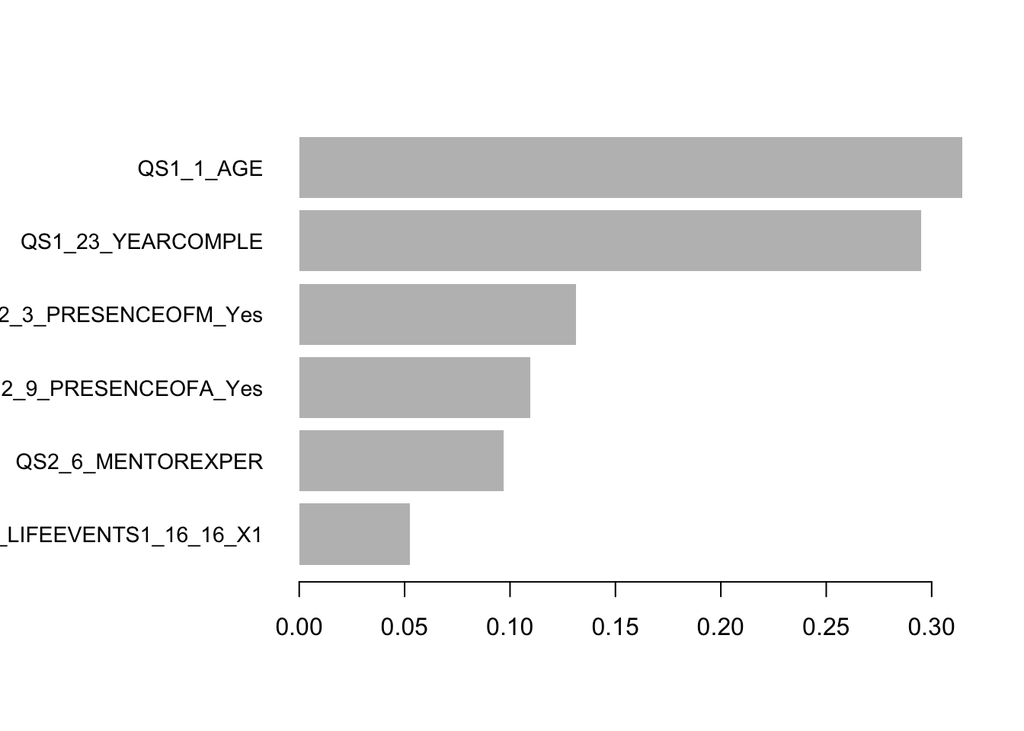

```r
xgb.plot.importance(xgb.importance(model = xgb_model))
```

```r
kable(xgb_importance_df)
```

| Feature | Gain | Cover | Frequency |
| --- | --- | --- | --- |
| QS1_1_AGE | 0.3146569 | 0.2746963 | 0.3092869 |
| QS1_23_YEARCOMPLE | 0.2948702 | 0.4865342 | 0.3250415 |
| QS2_3_PRESENCEOFM_Yes | 0.1314705 | 0.0392457 | 0.1036484 |
| QS2_9_PRESENCEOFA_Yes | 0.1095572 | 0.0340242 | 0.0837479 |
| QS2_6_MENTOREXPER | 0.0969891 | 0.1193217 | 0.1144279 |
| QS3_4_LIFEEVENTS1_16_16_X1 | 0.0524562 | 0.0461780 | 0.0638474 |

#### 7.4.0.3 XGB model 2:

#### 7.4.0.4 All 3 SES indicators, mentor experiences, and age.

```r
x <- model.matrix(~ QS3_4_LIFEEVENTS1_11_11_X1 + QS3_4_LIFEEVENTS1_16_16_X1 +  QS3_4_LIFEEVENTS1_18_18_X1 + QS2_3_PRESENCEOFM_Yes + QS2_9_PRESENCEOFA_Yes + QS2_6_MENTOREXPER + QS1_1_AGE, data = imputed_train)[, -1]

y <- log(imputed_train$QS1_28_EMPLOYMENT_calculated + 1)
dmatrix <- xgb.DMatrix(x, label = y)
xgb_model <- xgboost(data = dmatrix, nrounds = 100, objective = "reg:squarederror",
params = list(max_depth = 4, eta = 0.1))

xgb_importance_df <- xgb.importance(model = xgb_model)

xgb_cv <- xgb.cv(params = list(max_depth = 4, eta = 0.1), data = dmatrix, nrounds = 200, nfold = 5)
```

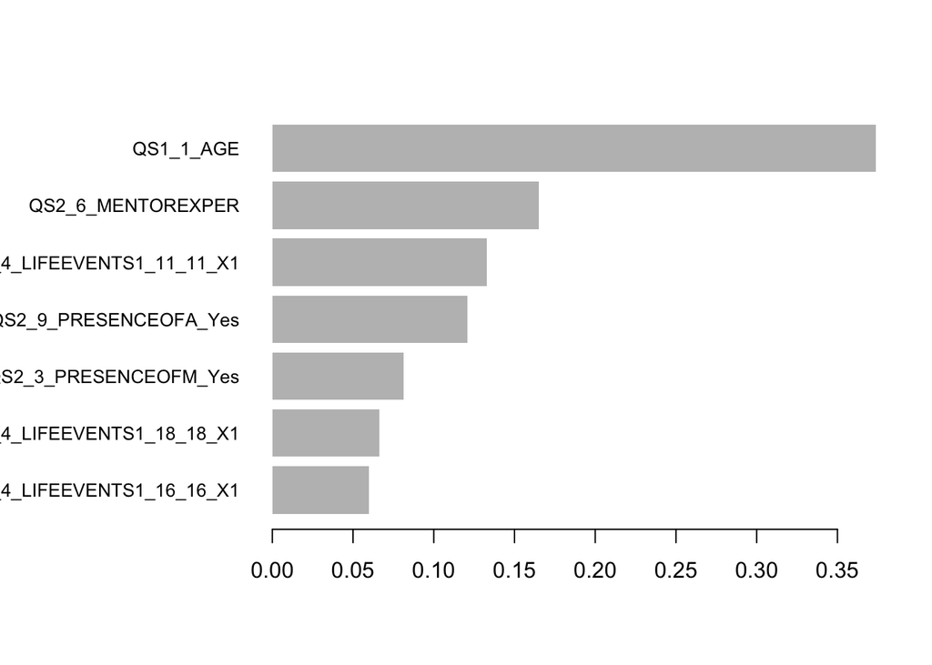

```r
xgb.plot.importance(xgb.importance(model = xgb_model))
```

```r
kable(xgb_importance_df)
```

| Feature | Gain | Cover | Frequency |
| --- | --- | --- | --- |
| QS1_1_AGE | 0.3739371 | 0.4450039 | 0.3834783 |
| QS2_6_MENTOREXPER | 0.1648597 | 0.1937742 | 0.1852174 |
| QS3_4_LIFEEVENTS1_11_11_X1 | 0.1328841 | 0.0566321 | 0.1104348 |
| QS2_9_PRESENCEOFA_Yes | 0.1208835 | 0.0628178 | 0.1069565 |
| QS2_3_PRESENCEOFM_Yes | 0.0812493 | 0.0606512 | 0.0739130 |
| QS3_4_LIFEEVENTS1_18_18_X1 | 0.0663133 | 0.1077789 | 0.0791304 |
| QS3_4_LIFEEVENTS1_16_16_X1 | 0.0598729 | 0.0733420 | 0.0608696 |